# Reproducible Research: Peer Assessment 1

```r
library(plyr)
library(dplyr)
library(lattice)
library(ggplot2)
```

## Loading and preprocessing the data

```r
activity.data <- read.csv("activity.csv")
```

## What is mean total number of steps taken per day?

Calculate the total number of steps taken per day.

```r
activity.by.date <- activity.data %>% group_by(date) %>%
  summarise(TotalSteps = sum(steps, na.rm = TRUE))
```

Make a histogram of the total number of steps taken each day.

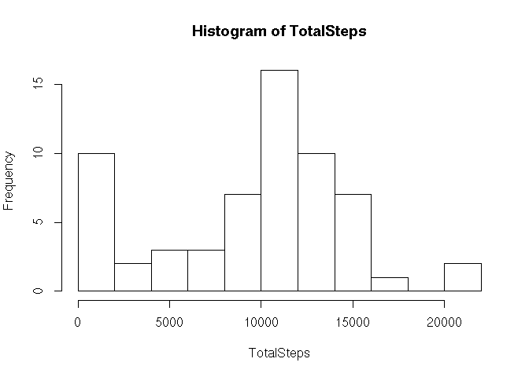

```r
with(activity.by.date, hist(TotalSteps, breaks=10))
```

Calculate and report the mean and median of the total number of steps taken per day.

```r
mean(activity.by.date$TotalSteps, na.rm = TRUE)
```

```
## [1] 9354.23
```

Median of total number of steps taken per day:

```r
median(activity.by.date$TotalSteps, na.rm = TRUE)
```

```
## [1] 10395
```

## What is the average daily activity pattern?

Make a time series plot of the 5-minute interval (x-axis) and the average number of steps taken, averaged across all days (y-axis)

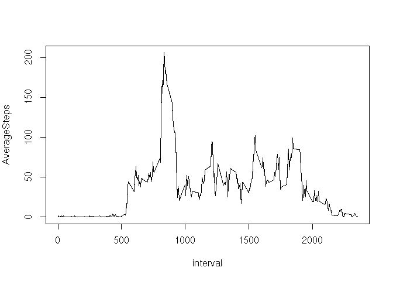

```r
activity.by.interval <- activity.data %>% group_by(interval) %>%
  summarise(AverageSteps = mean(steps, na.rm = TRUE))

with(activity.by.interval, plot(interval, AverageSteps, type="l"))
```

Which 5-minute interval, on average across all the days in the dataset, contains the maximum number of steps?

```r
with(activity.by.interval, interval[which.max(AverageSteps)])
```

```
## [1] 835
```

## Imputing missing values

Calculate and report the total number of missing values in the dataset (i.e. the total number of rows with NAs)

```r
sum(is.na(activity.data$steps))
```

```
## [1] 2304
```

Devise a strategy for filling in all of the missing values in the dataset. The strategy does not need to be sophisticated. For example, you could use the mean/median for that day, or the mean for that 5-minute interval, etc.

*We replace NA’s with average accross an interval*

Create a new dataset that is equal to the original dataset but with the missing data filled in.

```r
activity.clean <-
  ddply(activity.data, ~interval, transform,
        steps = replace(steps, is.na(steps), mean(steps, na.rm=TRUE)))
```

```r
activity.cleaned.by.date <- activity.clean %>% group_by(date) %>%
  summarise(TotalSteps = sum(steps, na.rm = TRUE))
```

Histogram

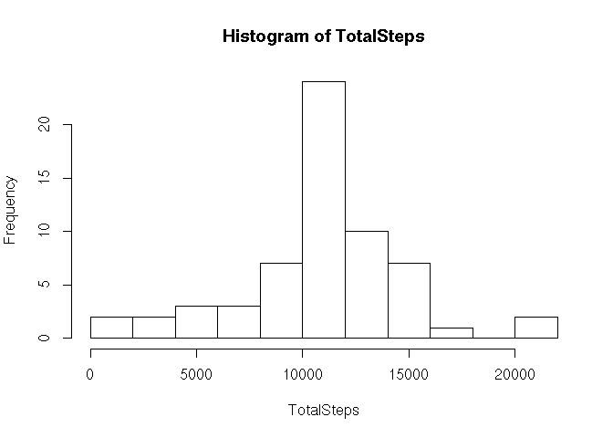

```r
with(activity.cleaned.by.date, hist(TotalSteps, breaks=10))
```

Mean

```r
mean(activity.cleaned.by.date$TotalSteps, na.rm = TRUE)
```

```
## [1] 10766.19
```

Median

```r
median(activity.cleaned.by.date$TotalSteps, na.rm = TRUE)
```

```
## [1] 10766.19
```

## Are there differences in activity patterns between weekdays and weekends?

Create a new factor variable in the dataset with two levels weekday and weekend indicating whether a given date is a weekday or weekend day.

```r
activity.data$DateType <-
  as.factor(
    ifelse(weekdays(as.Date(activity.data$date)) %in% c("Saturday", "Sunday"),
           "weekend",
           "weekday"))
```

Make a panel plot containing a time series plot (i.e. type = “l”) of the 5-minute interval (x-axis) and the average number of steps taken, averaged across all weekday days or weekend days (y-axis). See the README file in the GitHub repository to see an example of what this plot should look like using simulated data.

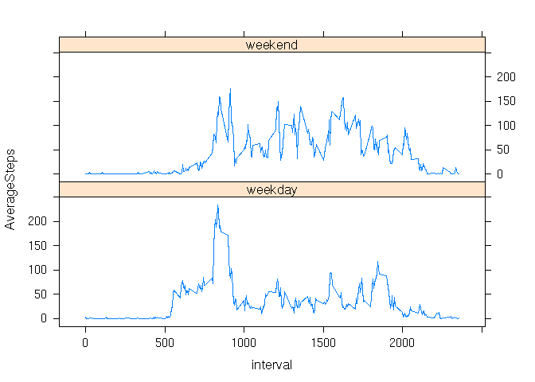

```r
activity.by.type_and_interval <- activity.data %>% group_by(interval, DateType) %>%
  summarise(AverageSteps = mean(steps, na.rm = TRUE))

xyplot(AverageSteps~interval | DateType,
       data=activity.by.type_and_interval,
       type="l", layout = c(1,2))
```